# Improving r2dii.match

How to work with big data, and benchmarks of a more efficient version of `match_name()`

Mauro Lepore https://github.com/maurolepore  
07-18-2020

[`match_name()`](https://2degreesinvesting.github.io/r2dii.match/reference/match_name.html) may [run out of memory if your data is too big](https://github.com/2DegreesInvesting/r2dii.match/issues/214). Most software for data analysis has a limit to how much data it can handle with a given hardware. If your data is too big to run `match_name()` on your computer, consider using only an informative subset of data or a more powerful computer. For example, here are some alternatives to consider:

1. Feed `match_name()` with data of only one sector, or part of one sector (see [`filter()`](https://dplyr.tidyverse.org/reference/filter.html)).
2. Feed `match_name()` with data of only the loans that make up most of the credit limit or outstanding credit limit. You might need just 20% of the data to capture 80% of the credit; more data might not change the overall result.
3. Run `match_name()` on a powerful [computer on the cloud](https://en.wikipedia.org/wiki/Cloud_computing#:~:text=Cloud%20computing%20is%20the%20on,many%20users%20over%20the%20Internet.).

Soon we’ll show examples of the approaches (1) and (2) above. Until then, you may want to watch RStudio’s webinar on [Working with Big Data in R](https://rstudio.com/resources/webinars/working-with-big-data-in-r/).

Packages:

```r
library(bench)
library(devtools)
library(dplyr)
library(fs)
library(ggplot2)
library(r2dii.data)
```

I’ll use the names *devel* and *cran* to refer to the versions of `match_name()` that are, respectively, *in development* and *on CRAN* (r2dii.match 0.0.3).

```r
# The older version on CRAN
packageVersion("r2dii.match")
```

```
#> [1] '0.0.3'
```

```r
# Copy of match_name on CRAN
cran <- r2dii.match::match_name

# The newer version in development
suppressMessages(devtools::load_all(fs::path_home("git", "r2dii.match")))
packageVersion("r2dii.match")
```

```
#> [1] '0.0.3.9000'
```

```r
# Copy of match_name in development
devel <- r2dii.match::match_name
```

Both versions have different source code:

```r
# Confirm the two versions of `match_name` are different
identical(devel, cran)
```

```
#> [1] FALSE
```

Compared to the version on CRAN, the version in development takes less time. It calls the expensive garbage collector fewer times, and at a more economic level. (I use `check = FALSE` because the output is not identical; the two outputs differ in the order of their rows, but if we reorder the rows in the same way, both outputs are equivalent.)

```r
benchmark <- bench::mark(
  check = FALSE,
  iterations = 30,
  matched_devel = matched_devel <- devel(loanbook_demo, ald_demo),
  matched_cran = matched_cran <- cran(loanbook_demo, ald_demo)
)

# No output means that the two expressions are indeed equivalent
testthat::expect_equivalent(
  matched_devel %>% arrange(across(names(.))),
  matched_cran %>% arrange(across(names(.)))
)

benchmark
```

```
#> # A tibble: 2 x 6
#>   expression         min   median `itr/sec` mem_alloc `gc/sec`
#>   <bch:expr>    <bch:tm> <bch:tm>     <dbl> <bch:byt>    <dbl>
#> 1 matched_devel 148.89ms 158.27ms     5.91         NA     4.73
#> 2 matched_cran     1.16s    1.51s     0.644        NA     4.72
```

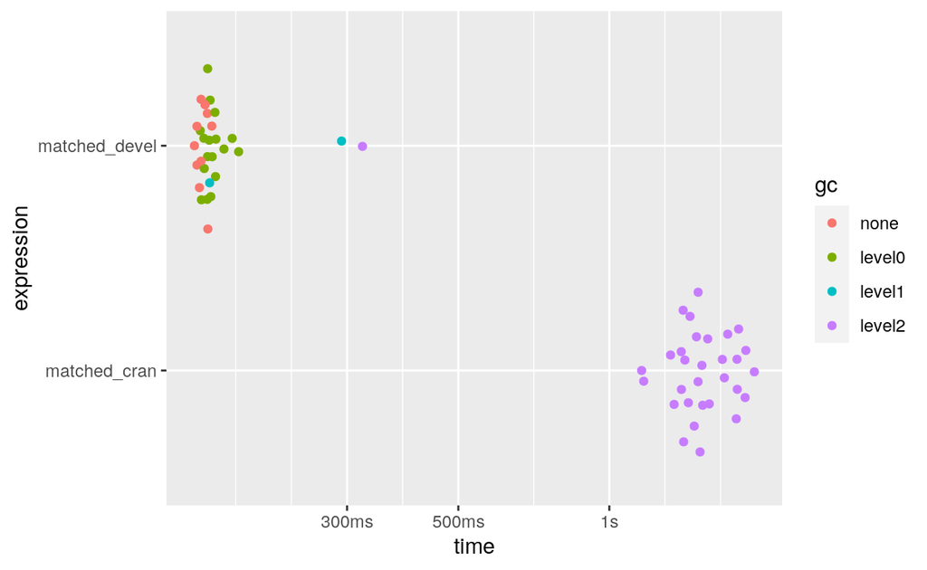

```r
ggplot2::autoplot(benchmark)
```

Thanks to your feedback, `match_name()` is becoming more efficient. We expect to release the improved version on CRAN soon.